# Presidential Elections: 1.1

Sono Shah

08/01/17

# Today’s Plan

- Course Description
- Course Policies
- First Lecture

# Introduction

- Instructor: Sono Shah
- Teaching Assistant: Stephanie DeMora-Rettberg

# Goals for this class

- Core concepts of presidential elections
- Introduce you to statistical software
- Get you working with real data from the 2016 Presidential Election

# Course Overview

- This is an upper-division political science class. I’m assuming you have a general understanding of American Politics, and how Presidential Elections work.
- If not, it’s ok :), That’s why I assigned the textbook and will post some other general readings to fill in the gaps.
- The purpose of this class is to take a deep dive into real data and undertand how these concepts work in the real world

# Readings

- *Campaigns & Elections* 2nd Edition
- Stuff on iLearn
- Online tutorials as needed

# Assignments/Grading

- Participation 10%
- Lab Assignmnents: 10 Total (50%)
- Final Paper 40%

# Pro Tips

- Read the Syllabus
- Ask us if you have questions

# Cooperative Congressional Elections Survey (CCES)

- Nationally Representative Sample of 64,600 American Adults
- Half of the questions asked of all respondents are called *Common Content*

# CCES

- 2/3 of survey is aksed *pre-election* (Late Sept. to end Oct.)
- topics include: general political attitudes, various demographic factors, assessment of roll call voting choices, and political information
- The rest of the questions are asked just after the election in November

# What the @!$^&! is R?

- open source programming language for statistical computing and data visualization
- We are going to use it to investigate the 2016 CCES Data

# Crosstabs

- What is a cross-tab?

|  | Donald Trump (R) | Hillary Clinton (D) | Other |
| --- | --- | --- | --- |
| Male | 0.210 | 0.199 | 0.045 |
| Female | 0.207 | 0.293 | 0.045 |

# What is a cross-tab? Part II

- What if I want to see presidential vote by gender?
- Table below shows **row** proportions

|  | Donald Trump (R) | Hillary Clinton (D) | Other |
| --- | --- | --- | --- |
| Male | 0.462 | 0.439 | 0.099 |
| Female | 0.380 | 0.538 | 0.082 |

# What is a cross-tab? Part III

- Table below shows **column** proportions

|  | Donald Trump (R) | Hillary Clinton (D) | Other |
| --- | --- | --- | --- |
| Male | 0.503 | 0.405 | 0.5 |
| Female | 0.497 | 0.595 | 0.5 |

# Data Visualization

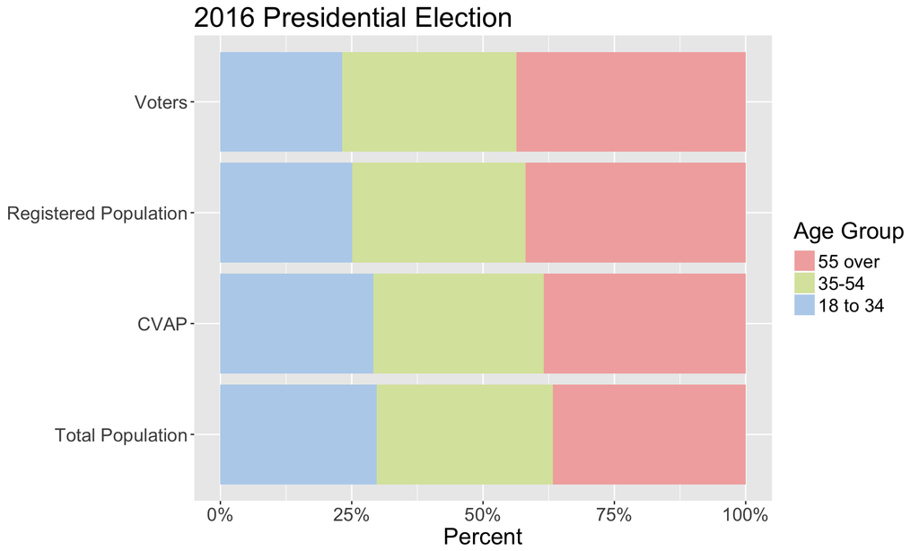

# Thinking about Presidential Elections as a Prediction Problem

- What is the central question that candidates, voters, political parties, interest groups, donors, etc. trying to figure out in a presidential election?

# Predicting Vote Choice

- What kinds of information would you want to predict how someone will vote in a presidential election?

# Hypothetical Person 1

- Name: John Smith
- Age: 47
- Race: Black

# Vote Choice?

> Vote Choice: Clinton

# Hypothetical Person 2

- Name: George
- Age: 35
- Race: Latino

# Vote Choice?

> Vote Choice: Trump

> Party Registration: Republican

# Hypothetical Person 3

- Name: Karen
- Age: 21
- Race: ??

# Vote Choice?

> Vote Choice: DIDN’T VOTE

> Registration Status: NOT REGISTERED

# Hypothetical Person 4

- Name: ??
- Age: 45
- Race: ??
- Education: Doctorate
- Gender: Female
- Marital Status: Single
- Vote Choice: Clinton

# Vote Choice?

> Vote Choice: Clinton

# What about other things?

- When asked “Whats the most important issue facing the country?”
- Person 1 said *Foreign Policy*
- Person 2 said *Terrorism*

# Vote Choice?

> Person 1: Clinton

> Person 2: Trump

# What about other things? II

- When Asked “What is your opinion of the federal government”
- Person 1 said *Government should do more*
- Person 2 said *Government doing too much*

# Vote Choice?

> Person 1: Clinton

> Person 2: Trump

# What about other things? III

- When Asked “Which candidate quality mattered most:”

> Cares about me

> Can bring change

> Right experience

# Vote Choice?

> Person 1: Trump

> Person 2: Clinton

# Today’s Lecture

- Chapter 1,2, and 9 of *Campaigns & Elections*

# Campaigns and Elections

- **rules** that govern elections
- broader **reality** (economic, political, and historical)
- **strategic choices** that various actors (candidates, media, parties, interest groups) make
- **choices of citizens**, who ultimately decide the outcome

# Rules

- who is qualified for office
- when the election is held
- how much money can be donated
- who is eligible to vote

# Reality

- Candidate biography
- records of political parties
- recent and current political and economic events

# Strategy

- which candidate
- what issues to emphasize
- what kinds of media to use
- which citizens to target

# Citizen’s Choices

- *Whether* to vote
- *Who* to vote for
- **Citizens are not blank slates**
- Which voters are up for grabs?

# Who Can Run For President?

- Must be 35 years old & US resident for at least 14 years
- Native-born citizen

# Who can run for President? II

- Is party affiliation necessary?

# Term limits?

- President can only serve two terms
- Is this a good idea?

# Primary Process

- Process by which candidates compete with others from **their** party for a particular offce
- Why do we have these?
- Open Versus Closed Primaries?
- Primaries versus Caucuses

# Goals of Presidential Elections

- Secure Party Nomination at National Convention
- Win enough states in the general election to get at least 270 Electoral College Votes

# Electoral College

- Each state has a number of electoral votes = to the number of representatives they have in the U.S. Congress
- House Members + 2 Senators
- 538 Total

# Electoral College II

- Creates Bias in favor of small states
- What would happen if this changed?

# [Vote Power by State](http://www.slate.com/articles/news_and_politics/map_of_the_week/2012/11/presidential_election_a_map_showing_the_vote_power_of_all_50_states.html)